# K-Fold Cross-Validation

Lisa Stuart

March 17, 2016

## K-Fold Cross-Validation

1. Set a seed for Reproducible Research and load boot package for cv.glm.
2. Split the n observations into K equally-sized folds.
3. For k = 1, …, K:
1. Fit the model using the observations not in the kth fold.
2. Let e_k denote the test error for the observations in the kth fold.
4. Calculate the sum over all errors of e_k, the total K-fold cross validation error.
- Note: When picking k, 5 and 10 work well.

Let’s see an example where we are just going to simulate some data to look at:

This code creates a training set with a 100 x 100 matrix of random normal variables (variables from a normal distribution, here with a mean 0 and standard deviation 1) with 100 columns. Then we’ll print the first 6 rows and the first 10 columns to get an idea of what the values look like.

```r
xtr = matrix(rnorm(100*100), ncol = 100)
xtr[1:6, 1:10]
```

```
##            [,1]       [,2]       [,3]       [,4]       [,5]       [,6]
## [1,]  0.2836919  0.8376384  0.1391224 -1.6808558  1.3948283 -0.5007627
## [2,]  0.4724783 -0.5666210  0.4086844 -1.2243384  1.2352307  0.3779963
## [3,] -0.6082152  1.1804859 -0.6313015 -0.4473359 -0.8498309 -1.3024369
## [4,] -1.3772602  0.7493935 -1.3665667 -0.5312040 -0.3268005  0.5232670
## [5,]  0.0010601 -1.7347408 -2.4223215  1.0663419  0.5171278  0.4770159
## [6,]  1.6861992 -0.4085241 -1.2636246  0.8097640 -0.9386713  1.5039897
##             [,7]       [,8]       [,9]      [,10]
## [1,] -1.02244996  0.0199241  0.5238373 -0.8266382
## [2,]  0.37690525  2.0447314  0.1458977 -1.1720699
## [3,]  1.07332403 -1.9695461  0.6762724 -0.9685655
## [4,]  0.82261078  1.6315379 -0.6425938 -0.4169655
## [5,]  1.09676690  0.1408246 -0.8924435  0.5171717
## [6,]  0.06088725 -0.3201969  0.1401330 -1.7732717
```

As you probably noticed, the values randomly bounce around 0, mostly between -1 and 1, with occasional values more extreme that represent values further away from the mean than 1 standard deviation.

Create a vector of beta values with 10 (good) signals and 90 junk variables.

```r
beta = c(rep(1,10), rep(0,90))
beta[1:15]
```

```
##  [1] 1 1 1 1 1 1 1 1 1 1 0 0 0 0 0
```

Create a vector of 100 response (y) variables for the simulated training data.

```r
ytr = xtr%*%beta + rnorm(100)
ytr[1:5]
```

```
## [1] -1.7519335  1.8949597 -2.5004036 -1.0966049 -0.7578657
```

Instantiate a NULL value for the training error to be used in the function that follows.

```r
cv.err = NULL
```

Create a function to fit a generalized linear model (GLM) and calculate the error.

```r
library(boot)
for(i in 2:50) {
    dat = data.frame(x=xtr[ ,1:i], y=ytr)
    mod = glm(y~., data = dat)
    cv.err = c(cv.err, cv.glm(dat, mod, K=6)$delta[1])
}
```

And plot 6-fold cross-validation error as a function of the number of variables with y on the log scale.

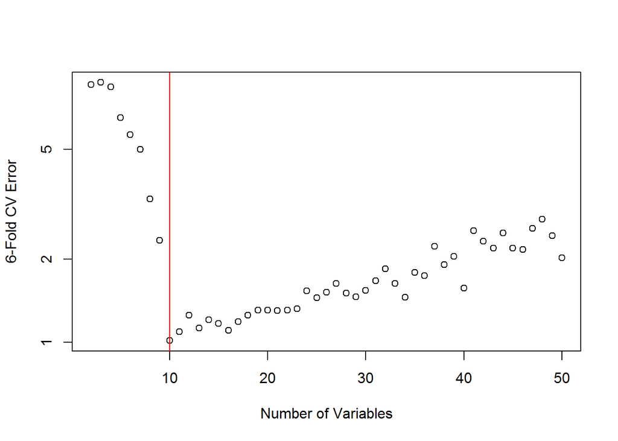